# ACT REPORT

## Introduction

For this project I got the chance to work with WeRateDogs Twitter account that gathers and comments on funny dog pictures. Part of my analysis involved number of retweets vs likes, what users are most likely to retweet and what breed is the most popular within the virtual community.

## Overall analysis and results visualization

I start first with a heat map. Using this type of visualization method I was able to have an overview of the relationship between variables where the higher the coefficient is, the stronger the relationship. It is clear that in my case the number of likes(favorites) and the number of retweets have a stong possitive correlation. Which means that as the retweets go up so do the likes. But for my suprise there was quite a big gap between these two types of reactions. There are more likes than retweets. So I went ahead and try to find why.

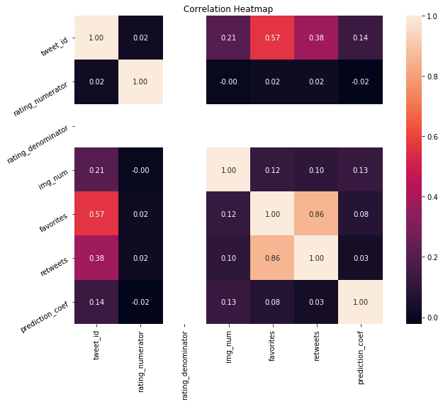

```python
# Fig1. Correlation Heat Map
```

Once I noticed that there are 12,144,577 more likes then retweet I looked more into that and what could cause it. I wanted to check if the divice of the user is related to that. I query dataset by the source type ( TweetDeck, Iphone and web client) and found the mean of the retweets. What I discovered and that also shows in the pie plot below is that users using iphone to browse on WeRateDogs are more likely to retweet, than the rest of the users.

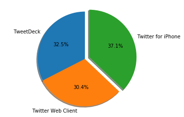

```python
# Figure2. Pie Plot showing users activity based on source(log in device).
```

Lastly, since this is a dog friendly dataset and analysis, I want to know what breed is liked the most within the virtual community. I subset the dataset to show the highest 25% favourites. Then grouped by breed.

> Here are top five most liked breeds on WeRateDogs:
> - golden_retriever with 1,479,573 likes
> - Labrador_retriever with 1,003,097 likes
> - Pembroke with 778,762 likes
> - Chihuahua with 570,232 likes
> - French_bulldog with 529,601 likes

## Which on is your favorite ?